# Habitat selection on spatially explicit landscapes

### Peter Zee // Feb 2018

### Introduction / Background

How does perception and choice among individuals influence patterns of colonization across heterogeneous landscapes?

### Model

#### Landscapes

-amount of uninhabitable matrix

-proportions of risky and safe patches

-spatial structure within local modules

-spatial structure among local modules

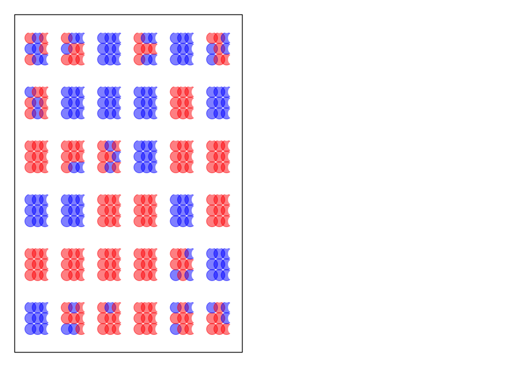

#### Individual dispersal

-dispersal for each indidual is determined by a dispersal kernal -dispersal kernals: individuals move in a random direction

-the dispersal kernal can be modified at each timestep depending on the type of habitat patch the individual encounters

-dispersal/movement can range from local (within modules) to more global (among local modules)

#### Colonization

-depending on the outcome of the decision-making behavior, individuals can colonize a habitat patch (e.g., oviposit)

-colonization can be a single time event, or multiple colonization events may occur

-number of eggs may vary among colonization events (i.e., diminishing returns in fecundity, proportions of total fecundity)

### Communities

Among species, at the community level, we can track how colonization dynamics within species influence community structure across the landscape.

### Evolution

We can model how population and community structures resulting from interactive habitat selection generate selection pressures on traits of interest. For example, such traits could be involved in individual decision-making behavior (e.g., perception, choice) or the response to stimuli (e.g., dispersal/movement modification with risk), or allocation of reproductive effort (i.e., proportion of total fecundity per patch).